# Máster en Data Science - Machine Learning

# Exploratory Data Analysis

##### Autor: Rodrigo Fernandez Campos

## DataSet: Bank Account Fraud Dataset Suite (NeurIPS 2022)

# **Análisis exploratorio gráfico + Train-Test Split**

En este notebook continuamos con el análisis exploratorio de datos, esta vez dando mayor preponderancia a aspectos gráficos y estadísticas descriptivas que nos permitan ahondar con mayor profundidad en el entendimiento del comportamiento de las variables. Además, llevamos a cabo una tarea importante de todo modelo de machine learning supervisado: la partición del set de datos en el set de entrenamiento y de testeo.

```python
# Librerías
import pandas as pd
import numpy as np
import matplotlib.pyplot as plt
import seaborn as sns
from sklearn.model_selection import train_test_split
from sklearn.impute import KNNImputer
from termcolor import colored, cprint
import scipy.stats as ss
import warnings
import sys

pd.set_option('display.max_columns', 500)
pd.set_option('display.max_rows', 500)
```

## Funciones

```python
sys.path.append('../src/')
import functions_rfc as fr
sys.path.remove('../src/')

### Constantes:
seed=10
```

## Importo el dataset

```python
df_fraud = pd.read_csv('../data/interim/df_fraud_1.csv')
df_fraud.head()
```

|  | Unnamed: 0 | fraud_bool | income | name_email_similarity | prev_address_months_count | current_address_months_count | customer_age | days_since_request | intended_balcon_amount | payment_type | zip_count_4w | velocity_6h | velocity_24h | velocity_4w | bank_branch_count_8w | date_of_birth_distinct_emails_4w | employment_status | credit_risk_score | email_is_free | housing_status | phone_home_valid | phone_mobile_valid | bank_months_count | has_other_cards | proposed_credit_limit | foreign_request | source | session_length_in_minutes | device_os | … |
| --- | --- | --- | --- | --- | --- | --- | --- | --- | --- | --- | --- | --- | --- | --- | --- | --- | --- | --- | --- | --- | --- | --- | --- | --- | --- | --- | --- | --- | --- | --- |
| 0 | 0 | 1 | 0.9 | 0.166828 | -1 | 88 | 50 | 0.020925 | -1.331345 | AA | 769 | 10650.765523 | 3134.319630 | 3863.647740 | 1 | 6 | CA | 185 | 0 | BA | 1 | 0 | 24 | 0 | 500.0 | 0 | INTERNET | 3.888115 | windows | … |
| 1 | 1 | 1 | 0.9 | 0.296286 | -1 | 144 | 50 | 0.005418 | -0.816224 | AB | 366 | 534.047319 | 2670.918292 | 3124.298166 | 718 | 3 | CA | 259 | 1 | BA | 0 | 0 | 15 | 0 | 1500.0 | 0 | INTERNET | 31.798819 | windows | … |
| 2 | 2 | 1 | 0.9 | 0.044985 | -1 | 132 | 40 | 3.108549 | -0.755728 | AC | 870 | 4048.534263 | 2893.621498 | 3159.590679 | 1 | 14 | CB | 177 | 1 | BA | 0 | 1 | -1 | 0 | 200.0 | 0 | INTERNET | 4.728705 | other | … |
| 3 | 3 | 1 | 0.9 | 0.159511 | -1 | 22 | 50 | 0.019079 | -1.205124 | AB | 810 | 3457.064063 | 4054.908412 | 3022.261812 | 1921 | 6 | CA | 110 | 1 | BA | 0 | 1 | 31 | 1 | 200.0 | 0 | INTERNET | 2.047904 | linux | … |
| 4 | 4 | 1 | 0.9 | 0.596414 | -1 | 218 | 50 | 0.004441 | -0.773276 | AB | 890 | 5020.341679 | 2728.237159 | 3087.670952 | 1990 | 2 | CA | 295 | 1 | BA | 1 | 0 | 31 | 0 | 1500.0 | 0 | INTERNET | 3.775225 | macintosh | … |

```python
df_fraud.info()
```

```
<class 'pandas.core.frame.DataFrame'>
RangeIndex: 1000000 entries, 0 to 999999
Data columns (total 32 columns):
 #   Column                            Non-Null Count    Dtype
---  ------                            --------------    -----
 0   Unnamed: 0                        1000000 non-null  int64
 1   fraud_bool                        1000000 non-null  int64
 2   income                            1000000 non-null  float64
 3   name_email_similarity             1000000 non-null  float64
 4   prev_address_months_count         1000000 non-null  int64
 5   current_address_months_count      1000000 non-null  int64
 6   customer_age                      1000000 non-null  int64
 7   days_since_request                1000000 non-null  float64
 8   intended_balcon_amount            1000000 non-null  float64
 9   payment_type                      1000000 non-null  object
```

[output cut: 24 more lines]

```python
# Elimino la primera columna que repite el Index
df_fraud = df_fraud.drop('Unnamed: 0',axis=1)
```

```python
# Descripción de los datos:
var_description = pd.read_excel('../data/interim/variables_description.xlsx')
var_description
```

|  | Variable | Type | Description | Possible Values / Range | Missings |
| --- | --- | --- | --- | --- | --- |
| 0 | fraud_bool | binary | TARGET - If the application is fraudulent or not. | [1 0] | NaN |
| 1 | income | numeric | Annual income of the applicant (in decile form). | [0.1 to 0.9] | NaN |
| 2 | name_email_similarity | numeric | Metric of similarity between email and applic... | [0.00 to 1.00] | NaN |
| 3 | prev_address_months_count | numeric | Number of months in previous registered addre... | [-1.00 to 383.00] | -1 |
| 4 | current_address_months_count | numeric | Months in currently registered address of the... | [-1.00 to 429.00] | -1 |
| 5 | customer_age | numeric | Applicant’s age in years, rounded to the decade. | [10 20 30 40 50 60 70 80 90] | NaN |
| 6 | days_since_request | numeric | Number of days passed since application was d... | [0.00 to 79] | NaN |
| 7 | intended_balcon_amount | numeric | Initial transferred amount for application. | [-16 to 114] | Negatives |
| 8 | payment_type | categorical | Credit payment plan type. 5 possible (annonym... | ['AA' 'AB' 'AC' 'AD' 'AE'] | NaN |
| 9 | zip_count_4w | numeric | Number of applications within same zip code i... | [1.00 to 6700.00] | NaN |
| 10 | velocity_6h | numeric | Velocity of total applications made in last 6... | [-175 to 16818] | NaN |
| 11 | velocity_24h | numeric | Velocity of total applications made in last 2... | [1297 to 9586] | NaN |
| 12 | velocity_4w | numeric | Velocity of total applications made in last 4... | [2825.75 to 7020] | NaN |
| 13 | bank_branch_count_8w | numeric | Number of total applications in the selected ... | [0 to 2404] | NaN |
| 14 | date_of_birth_distinct_emails_4w | numeric | Number of emails for applicants with same dat... | [0 to 39] | NaN |
| 15 | employment_status | categorical | Employment status of the applicant. 7 possibl... | ['CA' 'CB' 'CC' 'CD' 'CE' 'CF' 'CG'] | NaN |
| 16 | credit_risk_score | numeric | Internal score of application risk. | [-191.00 to 389.00] | NaN |
| 17 | email_is_free | binary | Domain of application email (either free or p... | [0 1] | NaN |
| 18 | housing_status | categorical | Current residential status for applicant. 7 p... | ['BA' 'BB' 'BC' 'BD' 'BE' 'BF' 'BG'] | NaN |
| 19 | phone_home_valid | binary | Validity of provided home phone. | [1 0] | NaN |
| 20 | phone_mobile_valid | binary | Validity of provided mobile phone. | [0 1] | NaN |
| 21 | bank_months_count | numeric | How old is previous account (if held) in months. | [-1 to 32] | -1 |
| 22 | has_other_cards | binary | If applicant has other cards from the same ba... | [0 1] | NaN |
| 23 | proposed_credit_limit | numeric | Applicant’s proposed credit limit. | [200 to 2100] | NaN |
| 24 | foreign_request | binary | If origin country of request is different fro... | [0 1] | NaN |
| 25 | source | categorical | Online source of application. Either browser ... | ['INTERNET' 'TELEAPP'] | NaN |
| 26 | session_length_in_minutes | numeric | Length of user session in banking website in ... | [-1.00 to 107] | -1 |
| 27 | device_os | categorical | Operative system of device that made request ... | ['windows' 'other' 'linux' 'macintosh' 'x11'] | NaN |
| 28 | keep_alive_session | binary | User option on session logout. | [0 1] | NaN |
| 29 | device_distinct_emails_8w | numeric | Number of distinct emails in banking website ... | [ 1 2 0 -1] | -1 |
| 30 | device_fraud_count | numeric | Number of fraudulent applications with used d... | [0 1] | NaN |
| 31 | month | numeric | Month where the application was made. | [0 1 2 3 4 5 6 7] | NaN |

## Cambio de tipo a variables categoricas

Cambio el tipo de las variables categóricas de texto a 'category'

```python
df_fraud[['payment_type','employment_status','housing_status','source','device_os']] =\
df_fraud[['payment_type','employment_status','housing_status','source','device_os']].astype("category")
```

```python
# vuelvo a generar mis listas por tipos de variables
df_fraud_bool, df_fraud_cat, df_fraud_num = fr.tipos_vars(df_fraud,False)
```

```python
cols_with_mis = ['prev_address_months_count'
            ,'current_address_months_count'
            ,'intended_balcon_amount'
            ,'bank_months_count'
            ,'session_length_in_minutes'
            ,'device_distinct_emails_8w']
```

# Separación Train-Test Stratified

Separaré el dataset en Train y Test manteniendo la proporción de la variable objetivo. Pero antes, graficaré la proporción actual de dicha variable.

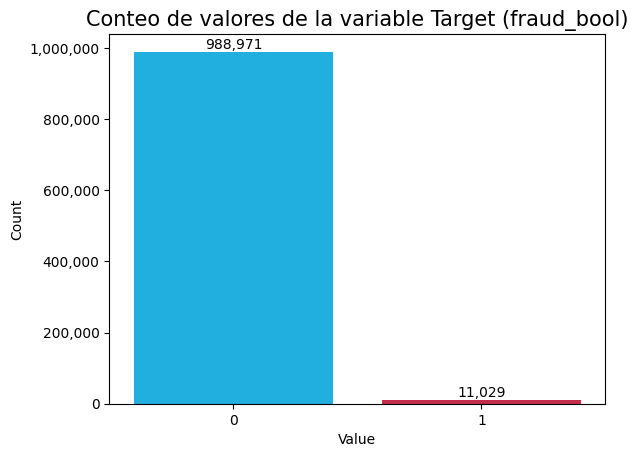

```python
target_count = df_fraud.groupby('fraud_bool').agg({'fraud_bool':'count'}).reset_index(drop=True)
target_count['value'] = list(target_count.index)

fig, ax = plt.subplots()
sns.barplot(data=target_count, x='value', y='fraud_bool', ax=ax, hue='fraud_bool',legend=False, palette=['crimson','deepskyblue'])
ax.set_title('Conteo de valores de la variable Target (fraud_bool)', fontdict={'fontsize':15}) #,'fontname':'Montserrat','weight':'bold'
ax.yaxis.set_major_formatter('{x:,.0f}')
for i in ax.containers:
    ax.bar_label(i,fmt='{:,.0f}')
ax.set_ylabel('Count')
ax.set_xlabel('Value')
plt.show()
```

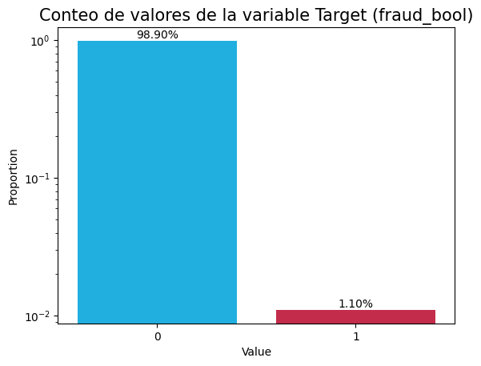

```python
target_perc = df_fraud.fraud_bool.value_counts(normalize=True).reset_index()

fig, ax = plt.subplots()
sns.barplot(data=target_perc, x='fraud_bool', y='proportion', ax=ax, hue='proportion',legend=False, palette=['crimson','deepskyblue'])
ax.set_title('Conteo de valores de la variable Target (fraud_bool)', fontdict={'fontsize':15}) #,'fontname':'Montserrat','weight':'bold'
#ax.yaxis.set_major_formatter('{x:,.0f}')
for i in ax.containers:
    ax.bar_label(i,fmt='{:.2%}')
plt.yscale('log')
ax.set_ylabel('Proportion')
ax.set_xlabel('Value')
plt.show()
```

```python
target_count
```

|  | fraud_bool | value |
| --- | --- | --- |
| 0 | 988971 | 0 |
| 1 | 11029 | 1 |

```python
df_fraud.fraud_bool.value_counts(normalize=True).reset_index()
```

|  | fraud_bool | proportion |
| --- | --- | --- |
| 0 | 0 | 0.988971 |
| 1 | 1 | 0.011029 |

Calculé y grafiqué los valores de la variable Target, no solo para volver a mostrar su distribución, sino también para combrobar que luego de llevar a cabo el split en train y test las proporciones se mantengan gracias a la estratificación.

```python
X_df_fraud_train, X_df_fraud_test, y_df_fraud_train, y_df_fraud_test = train_test_split(df_fraud.drop('fraud_bool',axis=1)
                                                                         ,df_fraud['fraud_bool']
                                                                         ,stratify=df_fraud['fraud_bool']
                                                                         ,test_size=0.3
                                                                         ,random_state=seed)
df_fraud_train = pd.concat([X_df_fraud_train, y_df_fraud_train],axis=1)
df_fraud_test = pd.concat([X_df_fraud_test, y_df_fraud_test],axis=1)
```

```python
print(f'''
\033[1mTRAIN\033[0m:
{y_df_fraud_train.value_counts(normalize=True)}

\033[1mTEST\033[0m:
{y_df_fraud_test.value_counts(normalize=True)}''')
```

```
TRAIN:
fraud_bool
0    0.988971
1    0.011029
Name: proportion, dtype: float64

TEST:
fraud_bool
0    0.98897
1    0.01103
Name: proportion, dtype: float64
```

La estratificación fue un éxito, tenemos la misma proporción tanto en Train como en Test

## Visualización de variables y su relación con el Target

```python
# realizo un redondeo de decimales en la variable income que no afecta en nada su valor pero es necesario para que su eje x se vea mejor
df_fraud_train['income'] = df_fraud_train['income'].round(3)
df_fraud_train.income.unique()
```

```
array([0.9, 0.1, 0.7, 0.4, 0.8, 0.5, 0.2, 0.3, 0.6])
```

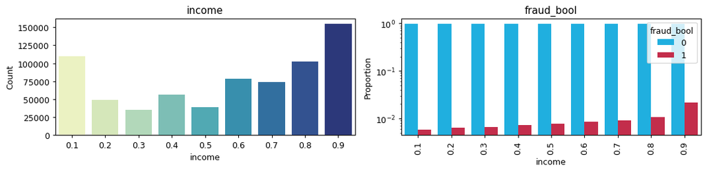

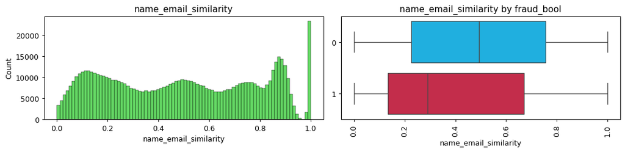

[figure not shown]

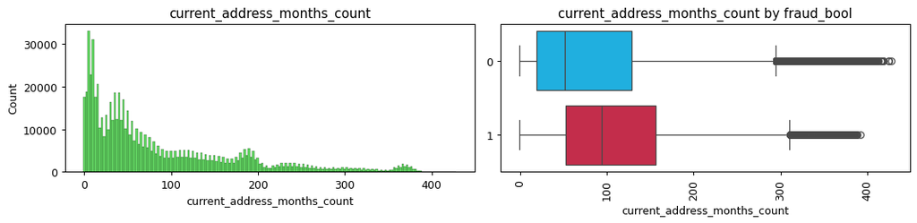

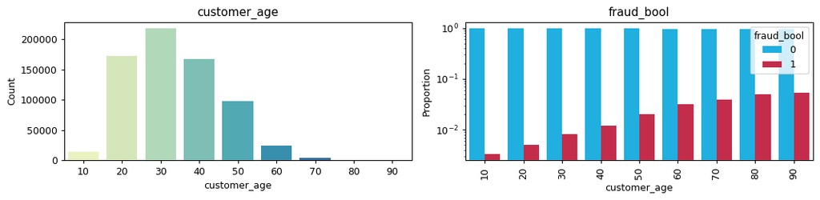

[figure not shown]

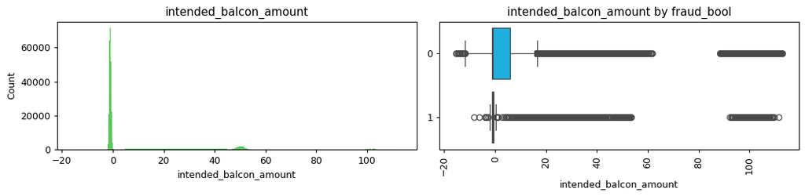

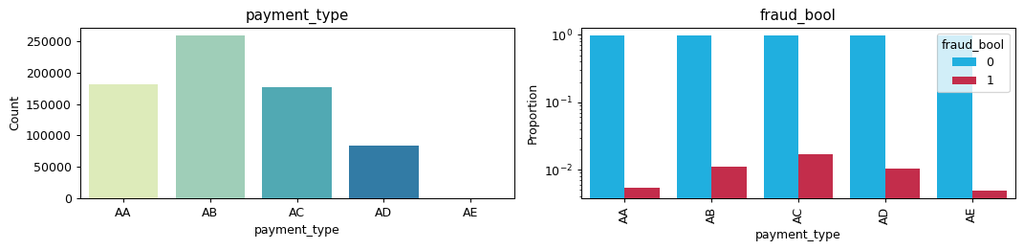

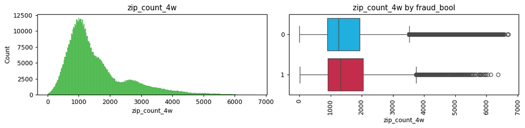

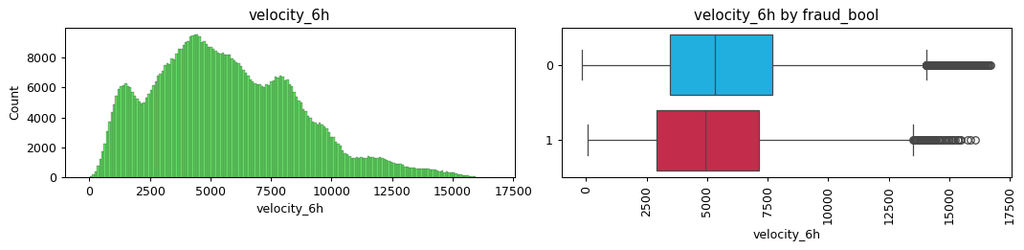

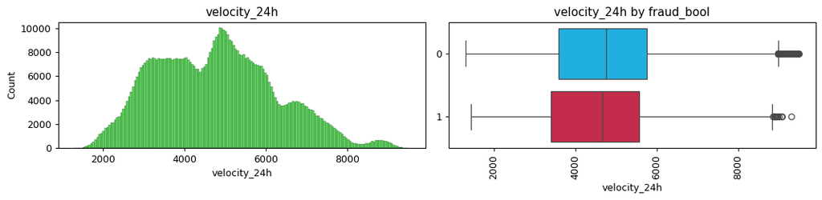

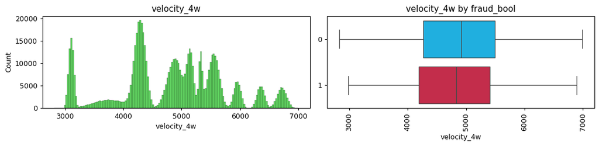

[18 more figures not shown]

```python
warnings.filterwarnings('ignore')
for i in list(df_fraud_train.columns):
    if i in df_fraud_num:
        fr.double_plot(df_fraud_train, col_name=i, is_cont=True, target='fraud_bool')
    elif  ((i in df_fraud_bool) | (i in df_fraud_cat)) & (i!='fraud_bool'):
        fr.double_plot(df_fraud_train, col_name=i, is_cont=False, target='fraud_bool')
```

# Detalles a tener en cuenta en base al análisis gráfico

Al analizar las variables visualmente salen a relucir algunos detalles que ya sabíamos, como la cantidad de missings en un par de variables que no hay que dejar pasar, pero sobre todo es interesante ver como algunas variables cambian su comportamiento en relación a la variable objetivo. Algunas anotaciones a tener en cuenta:

1. El fraude pareciese crecer con el decil de Income (variable cuya distribución parece agrandarse hacia los extremos), es decir que, si la codificación en deciles fue en orden ascendente como generalmente lo es, esto implicaría que ante un mayor ingreso anual declarado, mayor sería la probabilidad de fraude. Excepto a que la codificación fuese en orden descendente, en ese caso sería al revés, un menor ingreso significaría una mayor probabilidad de fraude.
2. El fraude parece aumentar un poco cuando el indicador de similitud entre en nombre del usuario y el email es más bajo.
3. El fraude pareciese crecer claramente con la edad.
4. Hay 2 o 3 variables que ya mencioné en el notebook anterior con valores missing, en ellas se ven los gráficos raros, debido a que gran parte de sus valores son Missings codificados como -1 y se toma a todo el resto como Outliers, por eso el BoxPlot saldrá raro. Pero bueno, ya hay un análisis puntual de dichas variables en el notebook 00.
5. Llaman la atención el employment status CB y sobre todo el CC, que a pesar de haber muchos menos registros de ese tipo, tiene de los mayores índices de fraude entre estos tipos. Aún así, es una variable descompensada debido a que la gran mayoría de los casos son CA.
6. El fraude pareciese aumentar conforme aumenta el score de riesgo crediticio. Obviamente no se trata de una relación lineal, pero se ve una tendencia en los boxplots. Algo similar sucede con el límite de crédito solicitado, aunque en menor medida.
7. El sistema operativo en el que más fraudes se producen es en Widows.
8. A pesar de tener menos registros, el housing_status BA es el que mayor índice de fraude posee.
9. A pesar de haber muy pocos registros mediante TELEAPP, el índice de fraudes es superior cuando la variable source toma ese valor. Lo mismo pasa cuando la aplicación es de un extrangero.
10. Al igual que pasa con el score de riesgo crediticio, el % de fraudes aumenta con el límite de crédito propuesto por el solicitante

No hay que perder de vista que la variable objetivo está muy desbalanceada, son muy pocos los registros con fraude (cerca del 1,1% del total de registros). Es posible que, antes de ejecutar el modelado, se requiera un procesamiento de oversampling para compensar un poco dicho desbalance.

```python
df_fraud_train.prev_address_months_count.describe()
```

```
count    700000.000000
mean         16.700337
std          44.047671
min          -1.000000
25%          -1.000000
50%          -1.000000
75%          12.000000
max         383.000000
Name: prev_address_months_count, dtype: float64
```

```python
df_fraud_train.days_since_request.describe()
```

```
count    7.000000e+05
mean     1.028231e+00
std      5.385380e+00
min      4.036860e-09
25%      7.192044e-03
50%      1.518232e-02
75%      2.635723e-02
max      7.845690e+01
Name: days_since_request, dtype: float64
```

# Tratamiento de Outliers

```python
fr.get_deviation_of_mean_perc(df_fraud_train, df_fraud_num, target='fraud_bool', multiplier=3)
```

|  | 0.0 | 1.0 | variable | sum_outlier_values | porcentaje_sum_null_values |
| --- | --- | --- | --- | --- | --- |
| 0 | 0.993956 | 0.006044 | prev_address_months_count | 17704 | 0.025291 |
| 1 | 0.984637 | 0.015363 | current_address_months_count | 15166 | 0.021666 |
| 2 | 0.989002 | 0.010998 | days_since_request | 12457 | 0.017796 |
| 3 | 0.989885 | 0.010115 | intended_balcon_amount | 13247 | 0.018924 |
| 4 | 0.991828 | 0.008172 | zip_count_4w | 11380 | 0.016257 |
| 5 | 0.994809 | 0.005191 | velocity_6h | 3082 | 0.004403 |
| 6 | 0.994924 | 0.005076 | velocity_24h | 394 | 0.000563 |
| 7 | 0.989564 | 0.010436 | bank_branch_count_8w | 28748 | 0.041069 |
| 8 | 0.969359 | 0.030641 | credit_risk_score | 2513 | 0.003590 |
| 9 | 0.979781 | 0.020219 | session_length_in_minutes | 16470 | 0.023529 |

1. Los valores que más llaman la atención son claramente los de 'credit_risk_score' y también, aunque en bastante menor medida, los de 'session_lenght_in_minutes', debido a que si tomamos en cuenta que el general en la variable target es que exista aproximadamente un 1% de fraude, en los outliers de estas dos variables se triplica y casi se duplica respectivamente esa posibilidad. Es algo a tener en cuenta, pero que **no debería afectar fuertemente a nuestras conclusiones ya que la cantidad de outliers es realmente baja en dichas variables.**
2. Por otro lado se debe destabar que en principio son muy bajos los porcentaje de outliers en prácticamente todas las variables y en general no parecen afectar significativamente a los resultados, por lo que por el momento procederé a manternerlos.

Al ser un problema de clasificación y por el hecho de ser pocos datos extremos, por el momento los mantendré, en todo caso podría hacer una CV sin ellos a la hora de modelar.

## Análisis de Relaciones entre las variables

### Correlation Matrix para variables numéricas

En este caso mostraré el índice de correlación entre las variables numéricas del dataset, aunque sin tener en cuenta las variables binarias. Si se tienen en cuenta variables que en el análisis se pueden tomar como categorías, pero que por sus valores numéricos vale la pena incluír dentro de este análisis de correlaciones, como puede ser el límite de crédito solicitado por ejemplo.

Solo agrego una variable binaria al final, que es la variable target, por curiosidad para ver si surge alguna correlación muy alta (algo que no esperaría que suceda a priori), aprovechando que es una variable codificada en 0 y 1.

```python
corr = pd.concat([df_fraud_train.select_dtypes('number').drop(df_fraud_bool, axis=1), df_fraud_train['fraud_bool']], axis=1).corr(method='pearson') # No usar variables Binarias
#corr = pd.concat([df_fraud_train[df_fraud_num],df_fraud_train['fraud_bool']], axis=1).corr(method='pearson')
corr
```

|  | income | name_email_similarity | prev_address_months_count | current_address_months_count | customer_age | days_since_request | intended_balcon_amount | zip_count_4w | velocity_6h | velocity_24h | velocity_4w | bank_branch_count_8w | date_of_birth_distinct_emails_4w | credit_risk_score | bank_months_count | proposed_credit_limit | session_length_in_minutes | device_distinct_emails_8w | month | fraud_bool |
| --- | --- | --- | --- | --- | --- | --- | --- | --- | --- | --- | --- | --- | --- | --- | --- | --- | --- | --- | --- | --- |
| income | 1.000000 | -0.039422 | 0.017866 | -0.036470 | 0.126833 | -0.016127 | 0.058749 | -0.080980 | -0.096385 | -0.100647 | -0.106521 | 0.007292 | -0.064140 | 0.170749 | -0.003900 | 0.107809 | -0.054352 | -0.009785 | 0.116257 | 0.045312 |
| name_email_similarity | -0.039422 | 1.000000 | -0.018414 | 0.050716 | -0.048689 | -0.008087 | 0.029623 | 0.024147 | 0.024726 | 0.036276 | 0.040217 | -0.000891 | 0.022773 | 0.048792 | -0.006377 | 0.073299 | 0.005507 | -0.018155 | -0.043687 | -0.036652 |
| prev_address_months_count | 0.017866 | -0.018414 | 1.000000 | -0.271548 | -0.068644 | 0.077734 | -0.009185 | -0.029569 | -0.001241 | 0.009052 | 0.004876 | -0.040040 | 0.060281 | -0.015029 | -0.045867 | -0.027874 | 0.052066 | 0.011548 | -0.000609 | -0.026123 |
| current_address_months_count | -0.036470 | 0.050716 | -0.271548 | 1.000000 | 0.142146 | -0.057592 | 0.056691 | 0.047082 | 0.027715 | 0.018662 | 0.026726 | 0.053898 | -0.173820 | 0.094928 | 0.072185 | 0.129962 | -0.034345 | -0.000426 | -0.025029 | 0.033498 |
| customer_age | 0.126833 | -0.048689 | -0.068644 | 0.142146 | 1.000000 | -0.035458 | -0.012504 | -0.015743 | -0.021881 | -0.009918 | -0.004947 | 0.048383 | -0.419654 | 0.165405 | 0.013187 | 0.148730 | 0.024809 | 0.025347 | 0.006848 | 0.062141 |
| days_since_request | -0.016127 | -0.008087 | 0.077734 | -0.057592 | -0.035458 | 1.000000 | 0.020986 | 0.000710 | 0.028529 | 0.023980 | 0.018016 | -0.017316 | 0.018435 | -0.087960 | -0.026950 | -0.068717 | 0.050033 | 0.011012 | -0.018027 | -0.000485 |
| intended_balcon_amount | 0.058749 | 0.029623 | -0.009185 | 0.056691 | -0.012504 | 0.020986 | 1.000000 | 0.002527 | 0.042182 | 0.064276 | 0.052130 | 0.102282 | -0.026799 | 0.002161 | 0.177667 | 0.057876 | 0.023542 | -0.020385 | -0.043768 | -0.024420 |
| zip_count_4w | -0.080980 | 0.024147 | -0.029569 | 0.047082 | -0.015743 | 0.000710 | 0.002527 | 1.000000 | 0.142087 | 0.201836 | 0.303334 | 0.005206 | 0.128109 | -0.103098 | 0.054114 | -0.012567 | 0.039972 | 0.020565 | -0.287721 | 0.004650 |
| velocity_6h | -0.096385 | 0.024726 | -0.001241 | 0.027715 | -0.021881 | 0.028529 | 0.042182 | 0.142087 | 1.000000 | 0.462981 | 0.399778 | 0.019444 | 0.118055 | -0.143347 | 0.014299 | -0.023963 | 0.054729 | 0.029298 | -0.408351 | -0.016972 |
| velocity_24h | -0.100647 | 0.036276 | 0.009052 | 0.018662 | -0.009918 | 0.023980 | 0.064276 | 0.201836 | 0.462981 | 1.000000 | 0.538613 | 0.035673 | 0.155601 | -0.146027 | 0.018049 | 0.017858 | 0.067733 | 0.034056 | -0.549123 | -0.011174 |
| velocity_4w | -0.106521 | 0.040217 | 0.004876 | 0.026726 | -0.004947 | 0.018016 | 0.052130 | 0.303334 | 0.399778 | 0.538613 | 1.000000 | 0.030826 | 0.242464 | -0.168084 | 0.032226 | 0.053171 | 0.079861 | 0.042090 | -0.848378 | -0.011716 |
| bank_branch_count_8w | 0.007292 | -0.000891 | -0.040040 | 0.053898 | 0.048383 | -0.017316 | 0.102282 | 0.005206 | 0.019444 | 0.035673 | 0.030826 | 1.000000 | -0.037884 | -0.014479 | 0.141471 | 0.009645 | 0.004423 | 0.003936 | -0.029331 | -0.011465 |
| date_of_birth_distinct_emails_4w | -0.064140 | 0.022773 | 0.060281 | -0.173820 | -0.419654 | 0.018435 | -0.026799 | 0.128109 | 0.118055 | 0.155601 | 0.242464 | -0.037884 | 1.000000 | -0.136722 | -0.009760 | -0.045068 | -0.030577 | -0.008362 | -0.245137 | -0.042996 |
| credit_risk_score | 0.170749 | 0.048792 | -0.015029 | 0.094928 | 0.165405 | -0.087960 | 0.002161 | -0.103098 | -0.143347 | -0.146027 | -0.168084 | -0.014479 | -0.136722 | 1.000000 | -0.061198 | 0.605916 | -0.034987 | -0.041176 | 0.175334 | 0.070244 |
| bank_months_count | -0.003900 | -0.006377 | -0.045867 | 0.072185 | 0.013187 | -0.026950 | 0.177667 | 0.054114 | 0.014299 | 0.018049 | 0.032226 | 0.141471 | -0.009760 | -0.061198 | 1.000000 | -0.023668 | 0.017639 | 0.004117 | -0.024480 | -0.002723 |
| proposed_credit_limit | 0.107809 | 0.073299 | -0.027874 | 0.129962 | 0.148730 | -0.068717 | 0.057876 | -0.012567 | -0.023963 | 0.017858 | 0.053171 | 0.009645 | -0.045068 | 0.605916 | -0.023668 | 1.000000 | -0.000885 | -0.017538 | -0.057523 | 0.068436 |
| session_length_in_minutes | -0.054352 | 0.005507 | 0.052066 | -0.034345 | 0.024809 | 0.050033 | 0.023542 | 0.039972 | 0.054729 | 0.067733 | 0.079861 | 0.004423 | -0.030577 | -0.034987 | 0.017639 | -0.000885 | 1.000000 | 0.077647 | -0.079828 | 0.008562 |
| device_distinct_emails_8w | -0.009785 | -0.018155 | 0.011548 | -0.000426 | 0.025347 | 0.011012 | -0.020385 | 0.020565 | 0.029298 | 0.034056 | 0.042090 | 0.003936 | -0.008362 | -0.041176 | 0.004117 | -0.017538 | 0.077647 | 1.000000 | -0.046937 | 0.035275 |
| month | 0.116257 | -0.043687 | -0.000609 | -0.025029 | 0.006848 | -0.018027 | -0.043768 | -0.287721 | -0.408351 | -0.549123 | -0.848378 | -0.029331 | -0.245137 | 0.175334 | -0.024480 | -0.057523 | -0.079828 | -0.046937 | 1.000000 | 0.013239 |
| fraud_bool | 0.045312 | -0.036652 | -0.026123 | 0.033498 | 0.062141 | -0.000485 | -0.024420 | 0.004650 | -0.016972 | -0.011174 | -0.011716 | -0.011465 | -0.042996 | 0.070244 | -0.002723 | 0.068436 | 0.008562 | 0.035275 | 0.013239 | 1.000000 |

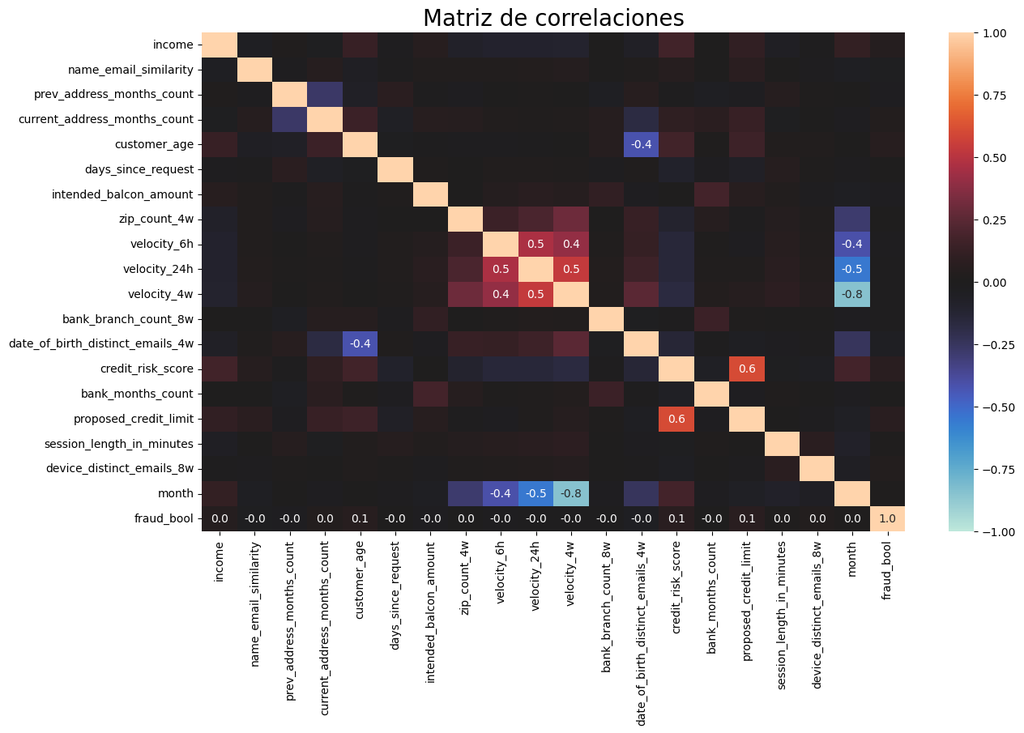

```python
fr.plot_corr(corr, target_text=True) # función propia importada, revisar en el .py de funciones en caso de querer entender su funcionamiento
```

Muestro la matriz de correlaciones, en donde solo destacan relaciones altas entre unas pocas variables. Comentaré las mismas luego de un pequeño análisis extra individual:

```python
new_corr = corr
new_corr.loc[:,:] = np.tril(new_corr, k=-1) # mantengo sólo una parte de las dos
new_corr = new_corr.stack().to_frame('correlation').reset_index().sort_values(by='correlation', ascending=False)
new_corr[(new_corr['correlation']>0.6) | (new_corr['correlation']<-0.6)].style.highlight_max('correlation',color='mistyrose').highlight_min('correlation',color='lightcyan')
```

|  | level_0 | level_1 | correlation |
| --- | --- | --- | --- |
| 313 | proposed_credit_limit | credit_risk_score | 0.605916 |
| 370 | month | velocity_4w | -0.848378 |

```python
vars_corr = ['proposed_credit_limit','credit_risk_score','month','velocity_4w']

fr.dame_info(vars_corr,df_fraud,var_description)
```

```
 1. proposed_credit_limit  :  Applicant’s proposed credit limit.
- Nulls: 0
- Range = [190.00 to 2100.00], Mean = 515.85

 2. credit_risk_score  :  Internal score of application risk.
- Nulls: 0
- Range = [-170.00 to 389.00], Mean = 130.99

 3. month  :  Month where the application was made.
- Nulls: 0
- Values: [0 1 2 3 4 5 6 7]

 4. velocity_4w  :  Velocity of total applications made in last 4 weeks, i.e., average number of applications per hour in the last 4 weeks.
- Nulls: 0
- Range = [2825.75 to 6994.76], Mean = 4856.32
```

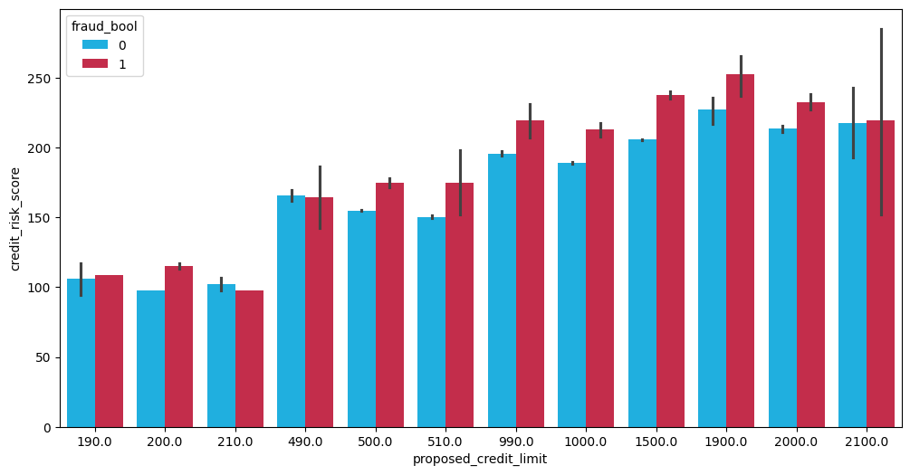

```python
plt.figure(figsize=(12,6))
sns.barplot(data=df_fraud_train,x='proposed_credit_limit',y='credit_risk_score', hue=df_fraud_train['fraud_bool'].astype('string'), palette=['deepskyblue','crimson'])
plt.show()
```

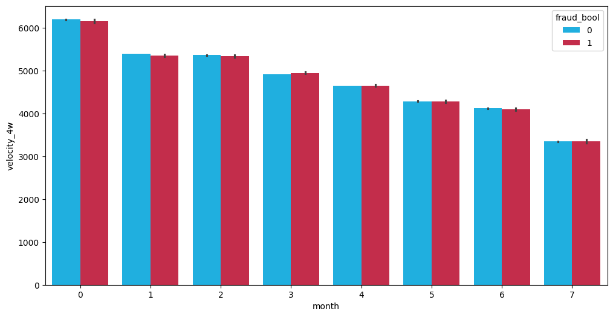

```python
plt.figure(figsize=(12,6))
sns.barplot(data=df_fraud_train,x='month',y='velocity_4w', hue=df_fraud_train['fraud_bool'].astype('string'), palette=['deepskyblue','crimson'])
plt.show()
```

De las variables analizadas podemos observar una clara correlación lineal y otra inversa:

1. Las variables del Score Crediticio y el Límite de Crédito Propuesto parecen tener cierta correlación positiva, lo cual es sorprendente debido a que esto implicaría que los que mayor riesgo crediticio poseen son los que mayor límite de crédito solicitan. De igual manera, la correlación no es tan alta como para implicar la necesidad de desacernos de una de las dos variables. Un feature engineering sería plausible de prueba, de alguna manera sacando un coeficiente entre ambas por ejemplo. *(Nota del futuro: no parece haber sido de gran utilidad al probar aplicar esto al modelo, en cualquier caso ver el notebook de la carpeta Experiments para verificarlo.*
2. Por otro lado, vemos que hay una clara correlación negativa entre el mes del análisis y el total de aplicaciones por hora promedio en 4 semanas. Esto indicaría que este promedio de aplicaciones en 4 semanas ha ido decayendo a lo largo de el tiempo, pero en principio no tenemos contexto de porque se da este suceso.

Además de estas correlaciones altas, no hay ninguna otra que destaque, y tampoco pareciesen resaltar muchas variables que expliquen de gran manera a nuestro Target, aunque si se puede ver que alguna lo hace mejor que otras:

```python
corr.loc['fraud_bool'].sort_values(ascending=False)
```

```
credit_risk_score                   0.070244
proposed_credit_limit               0.068436
customer_age                        0.062141
income                              0.045312
device_distinct_emails_8w           0.035275
current_address_months_count        0.033498
month                               0.013239
session_length_in_minutes           0.008562
zip_count_4w                        0.004650
fraud_bool                          0.000000
days_since_request                 -0.000485
bank_months_count                  -0.002723
velocity_24h                       -0.011174
bank_branch_count_8w               -0.011465
velocity_4w                        -0.011716
velocity_6h                        -0.016972
intended_balcon_amount             -0.024420
prev_address_months_count          -0.026123
name_email_similarity              -0.036652
date_of_birth_distinct_emails_4w   -0.042996
Name: fraud_bool, dtype: float64
```

Ninguna variable parece explicar en alta medida a la variable Target, algo que parece normal en un problema tan complejo como es la detección de este tipo de fraudes.

### Relaciones entre variables categóricas: Cramers V matrix

Con variables categóricas de tipo String no puedo hacer una matriz de correlaciones, pero realizaré un acercamiento mediante el estadístico Cramers V, usando una función de la cátedra para el cálculo del valor y mi propia función para crear una matriz con ese cálculo en bucles.

```python
df_fraud_cat_string = list(df_fraud_train[df_fraud_cat].select_dtypes('category').columns.values)
df_fraud_cat_string
```

```
['payment_type', 'employment_status', 'housing_status', 'source', 'device_os']
```

```python
confusion_matrix = pd.crosstab(df_fraud_train["fraud_bool"], df_fraud_train["payment_type"])
print(confusion_matrix)
fr.cramers_v(confusion_matrix.values)
```

```
payment_type      AA      AB      AC     AD   AE
fraud_bool
0             180017  256491  173431  82158  183
1                949    2952    2917    901    1
```

```
0.038659507530690425
```

```python
confusion_matrix = pd.crosstab(df_fraud_train["fraud_bool"], df_fraud_train["fraud_bool"])
fr.cramers_v(confusion_matrix.values)
```

```
0.9999345108159503
```

En base a los mismos cálculos que acabo de realizar, creo una matriz con las correlaciones de cramer obtenidas mediante una función de mi autoría:

```python
corr_cats = fr.corr_cat(df=df_fraud_train,target='fraud_bool',target_transform=True)
corr_cats
```

|  | payment_type | employment_status | housing_status | source | device_os | fraud_bool |
| --- | --- | --- | --- | --- | --- | --- |
| payment_type | 1.000000 | 0.056356 | 0.098518 | 0.062248 | 0.062298 | 0.038660 |
| employment_status | 0.056356 | 1.000000 | 0.107933 | 0.036544 | 0.058552 | 0.039161 |
| housing_status | 0.098518 | 0.107933 | 1.000000 | 0.023086 | 0.075161 | 0.114095 |
| source | 0.062248 | 0.036544 | 0.023086 | 0.999897 | 0.075201 | 0.002965 |
| device_os | 0.062298 | 0.058552 | 0.075161 | 0.075201 | 1.000000 | 0.080002 |
| fraud_bool | 0.038660 | 0.039161 | 0.114095 | 0.002965 | 0.080002 | 0.999935 |

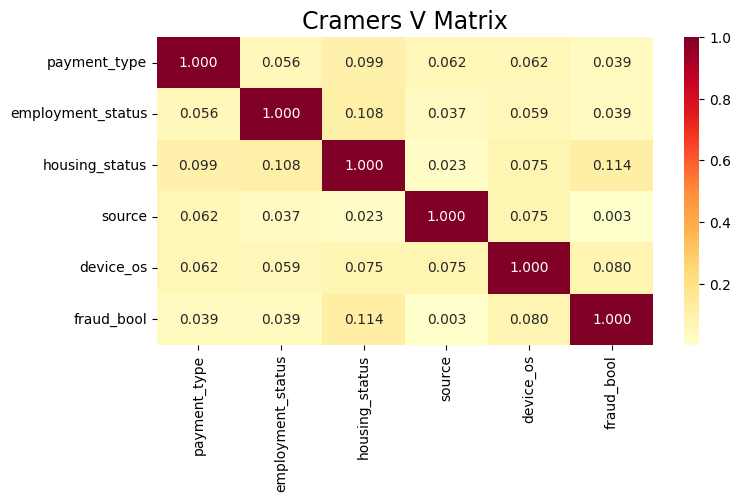

```python
plt.figure(figsize=(8,4))
sns.heatmap(corr_cats, annot=True, fmt='.3f', cmap='YlOrRd')
plt.title('Cramers V Matrix', fontdict={'size':'17'})
plt.show()
```

En la Matriz no hay muchas variables que destaquen por su alta correlación.

Si vemos la variable más relacionada a fraud_bool pareciese ser housing_status, pero es bastante débil (11%). Aún así pareciese tratarse de la relación más alta de esta matriz, por lo que junto al Riesgo Crediticio, podrán ser variables con cierta relevancia en el modelo, como ya pudimos ver también en los gráficos descriptivos.

```python
# Variables a codificar en el próximo notebook:
df_fraud_cat_string
```

```
['payment_type', 'employment_status', 'housing_status', 'source', 'device_os']
```

# Exporto los datasets

Hasta aquí llega este segundo notebook en donde, luego de realizar el split del dataset, se expusieron los gráficos y el análisis de las variables que componen al mismo.

El próximo paso será la codificación de las variables categóricas que han quedado de tipo String, una selección de variables en caso de que fuese necesario disminuír las dimensiones del DF por diferentes motivos y un posible escalado. Todo ello se encontrará en el Notebook 02.

Una vez terminado el EDA, procedemos a exportar los datasets definitivos de Train y Test con los que relizaremos nuestro modelo:

```python
df_fraud_train.to_csv('../data/interim/df_fraud_train.csv', index=False) # luego separaré nuevamente en X e y a la hora de modelar.
df_fraud_test.to_csv('../data/interim/df_fraud_test.csv', index=False) # lo mismo aplica para el test, se separará luego para no guardar dos csv separados.
```

# Conclusión del EDA

Una vez concluído el EDA, en donde se analizaron y preprocesaron los componentes del DataSet de este proyecto, ya conocemos y entendemos como se compone nuestro DataSet. El siguiente paso será realizar algunos preprocesamientos necesarios para que nuestros datos puedan ser procesador por los modelos que elijamos.

##### En este análisis hemos logrado:

- Conocer el significado y los valores de cada una de las variables
- Saber cuántos valores nulos, missings y outliers contiene nuestro dataset, para luego haber decidido cual sería su tratamiento.
- Comprender no solo el tipo de dato que contienen las variables analizadas, sino también su naturaleza y características, tanto para el análisis gráfico y descriptivo, como el de su futuro uso en nuestros modelos predictivos
- Entender que tratamos con un dataset desbalanceado, algo que resulta natural por la naturaleza del problema que abordamos, en donde los casos de fraude son absolutamente minoritarios en relación a los casos de no fraude en las aplicaciones de cuentas bancarias.
- Separar de manera estratificada al dataset en subsets de train y de test
- Realizar un análisis gráfico exhaustivo de todas las variables del dataset, destacando los principales detalles a tener en cuenta sobre ellas y sobre su relación con la variable objetivo.
- Comprender las corelaciones entre las variables, tanto numéricas como categóricas

Todo esto nos permitió entender que tratamos con un DataSet de muchas variables de varios tipos, con las cuales buscamos explicar y predecir el comportamiento de nuestra variable objetivo, es decir, cuando una aplicación puede ser fraudulenta y cuando no.

Dicho esto, está claro que nos enfrentamos a un problema extremadamente complejo desde el punto de vista de la medición del éxito de nuestros modelos, debido a que el modelo más simple de todos sería decir que NINGUNA transacción es fraudulenta, ya que sólo tendríamos error en el 1,1% de las veces. El objetivo será intentar mejorar esa marca agregándole complegidad a nuestro análisis.

##### En el próximo notebook se realizará el siguiente procesamiento:

- Encodificar las variables categóricas, convirtiendo sus valores en numéricos para poder procesarlas con éxito en los modelos que elijamos
- Realizar un escalado de todas las variables ya transformadas y preprocesadas por si necesitamos usarlo a la hora de aplicar nuestros modelos, sobre todo de regresión
- Separar el dataset de train en train y validation

### Detalles que deberemos tener en cuenta a la hora de ejecutar modelos:

- Podría ser efectivo y probablemente necesario el realizar un balanceado del modelo, con técnicas de oversampling por ejemplo.
- Hay variables que identificamos como importantes para predecir el fraude, como el credit risk score y el proposed credit limit, la edad, el income, el housing status, entre algunas otras.
- Por otro lado existe la posibilida de que algunas variables (como por ejemplo 'source') aporten poco, debido a que gran parte de sus valores son 0, se debería revisar su utilidad y en todo caso evaluar eliminar algunas variables del análisis si no aportan mucho valor.
- Hay que recordar eliminar una columna de device_os (OHE) si vamos a hacer modelos de regresión por ej., debido a que se podría duplicar información y generar un sesgo en modelos de este tipo.
- Posibilidad de realizar un Mean Encoding en vez de alguno de los ordinal en caso de que el modelo mejore de esta manera.